# 00_carga_datos

```python
import pandas as pd
import numpy as np
import matplotlib.pyplot as plt
import seaborn as sns
import sweetviz as sv
import openpyxl
```

```python
import os
print("Directorio actual:", os.getcwd())
```

```
Directorio actual: /Users/admin/Desktop/ap/practica1
```

```python
os.chdir('/Users/admin/Desktop/ap/practica1/data')
```

```python
# Cargar los archivos de datos
# Ruta relativa a la carpeta de datos
data = pd.read_csv('application_data.csv', delimiter=',')
```

```python
# Cargar el diccionario de variables
dictionary = pd.read_excel('columns_description.xlsx', engine='openpyxl')
print(dictionary.head())
```

```
   Unnamed: 0             Table                 Row  \
0           1  application_data          SK_ID_CURR
1           2  application_data              TARGET
2           5  application_data  NAME_CONTRACT_TYPE
3           6  application_data         CODE_GENDER
4           7  application_data        FLAG_OWN_CAR

                                         Description Special
0                           ID of loan in our sample     NaN
1  Target variable (1 - client with payment diffi...     NaN
2        Identification if loan is cash or revolving     NaN
3                               Gender of the client     NaN
4                      Flag if the client owns a car     NaN
```

```python
#Mostrar las primeras filas para verificar
print(data.head())
```

```
   SK_ID_CURR  TARGET NAME_CONTRACT_TYPE CODE_GENDER FLAG_OWN_CAR  \
0      100002       1         Cash loans           M            N
1      100003       0         Cash loans           F            N
2      100004       0    Revolving loans           M            Y
3      100006       0         Cash loans           F            N
4      100007       0         Cash loans           M            N

  FLAG_OWN_REALTY  CNT_CHILDREN  AMT_INCOME_TOTAL  AMT_CREDIT  AMT_ANNUITY  \
0               Y             0          202500.0    406597.5      24700.5
1               N             0          270000.0   1293502.5      35698.5
2               Y             0           67500.0    135000.0       6750.0
3               Y             0          135000.0    312682.5      29686.5
4               Y             0          121500.0    513000.0      21865.5

   ...  FLAG_DOCUMENT_18 FLAG_DOCUMENT_19 FLAG_DOCUMENT_20 FLAG_DOCUMENT_21  \
```

[output cut: 28 more lines]

```python
# Dimensiones del dataset
print("Dimensiones del dataset:")
print(data.shape)

# Tipos de datos
print("\nTipos de datos de las columnas:")
print(data.dtypes)

# Valores nulos
print("\nCantidad de valores nulos por columna:")
print(data.isnull().sum())
```

```
Dimensiones del dataset:
(307511, 122)

Tipos de datos de las columnas:
SK_ID_CURR                      int64
TARGET                          int64
NAME_CONTRACT_TYPE             object
CODE_GENDER                    object
FLAG_OWN_CAR                   object
                               ...
AMT_REQ_CREDIT_BUREAU_DAY     float64
AMT_REQ_CREDIT_BUREAU_WEEK    float64
AMT_REQ_CREDIT_BUREAU_MON     float64
AMT_REQ_CREDIT_BUREAU_QRT     float64
AMT_REQ_CREDIT_BUREAU_YEAR    float64
Length: 122, dtype: object

Cantidad de valores nulos por columna:
SK_ID_CURR                        0
TARGET                            0
NAME_CONTRACT_TYPE                0
CODE_GENDER                       0
FLAG_OWN_CAR                      0
                              ...
AMT_REQ_CREDIT_BUREAU_DAY     41519
AMT_REQ_CREDIT_BUREAU_WEEK    41519
AMT_REQ_CREDIT_BUREAU_MON     41519
AMT_REQ_CREDIT_BUREAU_QRT     41519
AMT_REQ_CREDIT_BUREAU_YEAR    41519
Length: 122, dtype: int64
```

#### 1. Dimesiones del data set

- El dataset contiene 307,511 filas (observaciones o registros) y 122 columnas (variables).
- Cada fila representa una persona o cliente, y las columnas son las características asociadas a cada uno.

#### 2. Tipos de datos

- int64: Variables numéricas enteras. Por ejemplo, SK_ID_CURR parece ser un identificador único de cliente y TARGET es el objetivo que estamos tratando de analizar.
- object: Variables categóricas o texto. Por ejemplo, NAME_CONTRACT_TYPE podría indicar el tipo de contrato y CODE_GENDER el género.
- float64 (mostrado más adelante): Variables numéricas decimales, como las solicitudes de crédito (AMT_REQ_CREDIT_BUREAU_DAY).

#### 3. Valores nulos

- Columnas con 0 valores nulos: Estas variables están completas, es decir, no tienen datos faltantes.
  - Ejemplo: SK_ID_CURR, TARGET, CODE_GENDER no tienen valores nulos.
- Columnas con valores nulos (como AMT_REQ_CREDIT_BUREAU_YEAR):
  - Esta columna tiene 41,519 valores nulos, lo que representa una proporción significativa del total.

```python
# Estadísticas descriptivas
print("\nEstadísticas descriptivas:")
print(data.describe())
```

```
Estadísticas descriptivas:
          SK_ID_CURR         TARGET   CNT_CHILDREN  AMT_INCOME_TOTAL  \
count  307511.000000  307511.000000  307511.000000      3.075110e+05
mean   278180.518577       0.080729       0.417052      1.687979e+05
std    102790.175348       0.272419       0.722121      2.371231e+05
min    100002.000000       0.000000       0.000000      2.565000e+04
25%    189145.500000       0.000000       0.000000      1.125000e+05
50%    278202.000000       0.000000       0.000000      1.471500e+05
75%    367142.500000       0.000000       1.000000      2.025000e+05
max    456255.000000       1.000000      19.000000      1.170000e+08

         AMT_CREDIT    AMT_ANNUITY  AMT_GOODS_PRICE  \
count  3.075110e+05  307499.000000     3.072330e+05
mean   5.990260e+05   27108.573909     5.383962e+05
std    4.024908e+05   14493.737315     3.694465e+05
min    4.500000e+04    1615.500000     4.050000e+04
25%    2.700000e+05   16524.000000     2.385000e+05
50%    5.135310e+05   24903.000000     4.500000e+05
75%    8.086500e+05   34596.000000     6.795000e+05
max    4.050000e+06  258025.500000     4.050000e+06

       REGION_POPULATION_RELATIVE     DAYS_BIRTH  DAYS_EMPLOYED  ...  \
count               307511.000000  307511.000000  307511.000000  ...
mean                     0.020868  -16036.995067   63815.045904  ...
std                      0.013831    4363.988632  141275.766519  ...
min                      0.000290  -25229.000000  -17912.000000  ...
25%                      0.010006  -19682.000000   -2760.000000  ...
50%                      0.018850  -15750.000000   -1213.000000  ...
75%                      0.028663  -12413.000000    -289.000000  ...
max                      0.072508   -7489.000000  365243.000000  ...

       FLAG_DOCUMENT_18  FLAG_DOCUMENT_19  FLAG_DOCUMENT_20  FLAG_DOCUMENT_21  \
count     307511.000000     307511.000000     307511.000000     307511.000000
mean           0.008130          0.000595          0.000507          0.000335
std            0.089798          0.024387          0.022518          0.018299
min            0.000000          0.000000          0.000000          0.000000
25%            0.000000          0.000000          0.000000          0.000000
50%            0.000000          0.000000          0.000000          0.000000
75%            0.000000          0.000000          0.000000          0.000000
max            1.000000          1.000000          1.000000          1.000000
```

[output cut: 17 more lines]

```
50%                      0.000000                   0.000000
75%                      0.000000                   0.000000
max                      8.000000                  27.000000

       AMT_REQ_CREDIT_BUREAU_QRT  AMT_REQ_CREDIT_BUREAU_YEAR
count              265992.000000               265992.000000
mean                    0.265474                    1.899974
std                     0.794056                    1.869295
min                     0.000000                    0.000000
25%                     0.000000                    0.000000
50%                     0.000000                    1.000000
75%                     0.000000                    3.000000
max                   261.000000                   25.000000

[8 rows x 106 columns]
```

```python
# Relación entre las columnas del dataset y el diccionario
print("\nRelación entre columnas del dataset y diccionario de variables:")
print(dictionary[['Row', 'Description']])
```

```
Relación entre columnas del dataset y diccionario de variables:
                           Row  \
0                   SK_ID_CURR
1                       TARGET
2           NAME_CONTRACT_TYPE
3                  CODE_GENDER
4                 FLAG_OWN_CAR
..                         ...
155             DAYS_FIRST_DUE
156  DAYS_LAST_DUE_1ST_VERSION
157              DAYS_LAST_DUE
158           DAYS_TERMINATION
159  NFLAG_INSURED_ON_APPROVAL

                                           Description
0                             ID of loan in our sample
1    Target variable (1 - client with payment diffi...
2          Identification if loan is cash or revolving
3                                 Gender of the client
4                        Flag if the client owns a car
..                                                 ...
155  Relative to application date of current applic...
156  Relative to application date of current applic...
157  Relative to application date of current applic...
158  Relative to application date of current applic...
159  Did the client requested insurance during the ...

[160 rows x 2 columns]
```

```python
# Porcentaje de valores nulos por columna
missing_values = (data.isnull().sum() / len(data)) * 100
missing_values = missing_values[missing_values > 0]  # Filtrar columnas con valores nulos
missing_values = missing_values.sort_values(ascending=False)

print("Porcentaje de valores nulos por columna:")
print(missing_values)
```

```
Porcentaje de valores nulos por columna:
COMMONAREA_MEDI             69.872297
COMMONAREA_AVG              69.872297
COMMONAREA_MODE             69.872297
NONLIVINGAPARTMENTS_MEDI    69.432963
NONLIVINGAPARTMENTS_MODE    69.432963
                              ...
EXT_SOURCE_2                 0.214626
AMT_GOODS_PRICE              0.090403
AMT_ANNUITY                  0.003902
CNT_FAM_MEMBERS              0.000650
DAYS_LAST_PHONE_CHANGE       0.000325
Length: 67, dtype: float64
```

```python
import plotly
print("Plotly está instalado correctamente. Versión:", plotly.__version__)
```

```
Plotly está instalado correctamente. Versión: 5.24.1
```

```python
# Calcular proporción de cada clase en TARGET
target_distribution = data['TARGET'].value_counts(normalize=True).mul(100).reset_index()
target_distribution.columns = ['TARGET', 'percent']

# Calcular el conteo absoluto de cada clase
target_counts = data['TARGET'].value_counts().reset_index()
target_counts.columns = ['TARGET', 'count']

# Mostrar la distribución
print("Distribución de TARGET (proporción y conteo):")
print(pd.concat([target_distribution, target_counts['count']], axis=1))

# Graficar distribución de TARGET
fig = px.bar(target_distribution, x="TARGET", y="percent", title="Distribución de la variable TARGET", text="percent")
fig.update_traces(texttemplate='%{text:.2f}%', textposition='outside')
fig.update_layout(xaxis_title="TARGET", yaxis_title="Porcentaje")
fig.show()
```

```
Distribución de TARGET (proporción y conteo):
   TARGET    percent   count
0       0  91.927118  282686
1       1   8.072882   24825
```

```
Distribución de TARGET:
   TARGET   count    percent
0       0  282686  91.927118
1       1   24825   8.072882
```

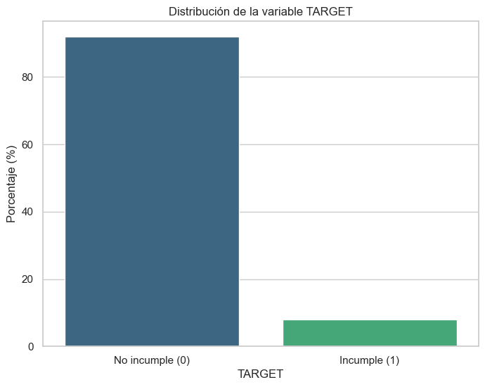

```python
# Proporción y conteo de clases en TARGET
target_distribution = data['TARGET'].value_counts(normalize=True).mul(100).rename('percent')
target_count = data['TARGET'].value_counts()

# Crear un DataFrame para organizar los resultados
target_analysis = pd.DataFrame({
    'TARGET': target_count.index,
    'count': target_count.values,
    'percent': target_distribution.values
})

print("Distribución de TARGET:")
print(target_analysis)

# Gráfico de barras de la distribución de TARGET con Matplotlib
plt.figure(figsize=(8, 6))
sns.barplot(x=target_analysis['TARGET'], y=target_analysis['percent'], palette="viridis")
plt.title("Distribución de la variable TARGET")
plt.xlabel("TARGET")
plt.ylabel("Porcentaje (%)")
plt.xticks([0, 1], ['No incumple (0)', 'Incumple (1)'])
plt.show()

# Gráfico interactivo con Plotly
fig = px.bar(
    target_analysis, x='TARGET', y='percent',
    title="Distribución de la variable TARGET",
    text='percent'
)
fig.update_traces(texttemplate='%{text:.2f}%', textposition='outside')
fig.update_layout(xaxis=dict(tickmode='array', tickvals=[0, 1], ticktext=['No incumple (0)', 'Incumple (1)']))
fig.show()
```

La gráfica muestra la distribución de la variable objetivo TARGET, donde se observa que el 91.93% de los clientes no incumplen con sus pagos (TARGET = 0), mientras que solo el 8.07% presentan incumplimiento (TARGET = 1).

# Selección de threshold por filas y columnas para eliminar valores missing

```python
# Calcular valores nulos por columnas y filas
null_columns = data.isnull().sum().sort_values(ascending=False)  # Valores nulos por columna
null_rows = data.isnull().sum(axis=1).sort_values(ascending=False)  # Valores nulos por fila

# Mostrar las dimensiones
print(f"Dimensiones de valores nulos por columnas: {null_columns.shape}")
print(f"Dimensiones de valores nulos por filas: {null_rows.shape}")

# Crear DataFrames para análisis
null_columns_df = pd.DataFrame(null_columns, columns=['nulos_columnas'])
null_rows_df = pd.DataFrame(null_rows, columns=['nulos_filas'])

# Agregar porcentaje de nulos
null_columns_df['porcentaje_columnas'] = null_columns_df['nulos_columnas'] / data.shape[0]
null_rows_df['porcentaje_filas'] = null_rows_df['nulos_filas'] / data.shape[1]

# Si deseas agregar información sobre TARGET a las filas:
null_rows_df['TARGET'] = data['TARGET'].copy()

# Mostrar resultados
print("Valores nulos por columnas (ordenado):")
print(null_columns_df)

print("\nValores nulos por filas (ordenado):")
print(null_rows_df)
```

```
Dimensiones de valores nulos por columnas: (122,)
Dimensiones de valores nulos por filas: (307511,)
Valores nulos por columnas (ordenado):
                          nulos_columnas  porcentaje_columnas
COMMONAREA_MEDI                   214865             0.698723
COMMONAREA_AVG                    214865             0.698723
COMMONAREA_MODE                   214865             0.698723
NONLIVINGAPARTMENTS_MODE          213514             0.694330
NONLIVINGAPARTMENTS_AVG           213514             0.694330
...                                  ...                  ...
NAME_HOUSING_TYPE                      0             0.000000
NAME_FAMILY_STATUS                     0             0.000000
NAME_EDUCATION_TYPE                    0             0.000000
NAME_INCOME_TYPE                       0             0.000000
SK_ID_CURR                             0             0.000000

[122 rows x 2 columns]

Valores nulos por filas (ordenado):
        nulos_filas  porcentaje_filas  TARGET
185713           61               0.5       0
133770           61               0.5       0
197736           61               0.5       0
116937           61               0.5       0
269492           61               0.5       0
...             ...               ...     ...
129942            0               0.0       0
129929            0               0.0       0
129924            0               0.0       0
129911            0               0.0       0
153755            0               0.0       0

[307511 rows x 3 columns]
```

**Selección de threshold por filas y columnas para valores nulos**

El análisis de los valores nulos revela lo siguiente:

**Por columnas:**

Existen 122 columnas en el dataset, de las cuales varias tienen un porcentaje significativo de valores nulos.

Las columnas COMMONAREA_MED, COMMONAREA_AVG y COMMONAREA_MODE presentan cerca del 69.87% de valores faltantes, lo que las hace candidatas para ser eliminadas o imputadas según su relevancia en el análisis.

Algunas columnas, como NAME_HOUSING_TYPE y NAME_EDUCATION_TYPE, no presentan valores nulos y están completas. Por filas:

Hay 307,511 filas en el dataset, y un número considerable tiene hasta un 50% de sus valores faltantes.

Esto podría indicar la necesidad de aplicar un threshold para eliminar estas filas, especialmente si contienen poca información relevante. Relevancia de TARGET en las filas con nulos:

Se incluyó la variable TARGET para observar cómo se distribuyen los valores faltantes en relación con la variable objetivo. Esto permitirá evaluar si las filas con más nulos tienen una relación significativa con el incumplimiento (TARGET = 1).

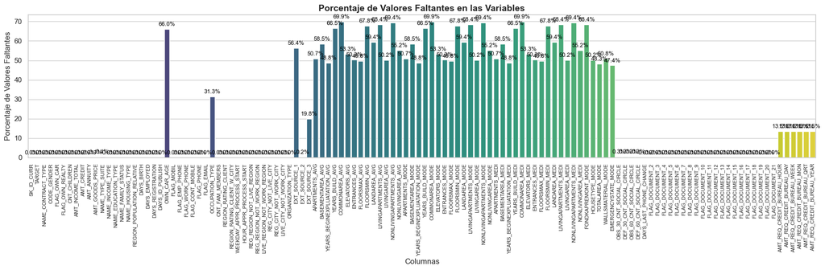

```python
# Calcular el porcentaje de valores faltantes
missing = pd.DataFrame((data.isnull().sum()) * 100 / data.shape[0]).reset_index()
missing.columns = ['Column', 'Missing_Percentage']

# Configurar el gráfico con estilo mejorado
plt.figure(figsize=(18, 6))
sns.set_theme(style="whitegrid")
ax = sns.barplot(x='Column', y='Missing_Percentage', data=missing, palette='viridis')

# Personalizar etiquetas y diseño
plt.xticks(rotation=90, fontsize=8)
plt.title("Porcentaje de Valores Faltantes en las Variables", fontsize=14, fontweight='bold')
plt.ylabel("Porcentaje de Valores Faltantes", fontsize=12)
plt.xlabel("Columnas", fontsize=12)

# Añadir etiquetas encima de las barras
for p in ax.patches:
    percentage = f"{p.get_height():.1f}%"
    ax.annotate(percentage, (p.get_x() + p.get_width() / 2., p.get_height()),
                ha='center', va='baseline', fontsize=9, color='black', xytext=(0, 5), textcoords='offset points')

# Mostrar el gráfico
plt.tight_layout()
plt.show()
```

El gráfico muestra el porcentaje de valores faltantes en cada una de las variables del dataset. En el eje horizontal se encuentran los nombres de las columnas, mientras que el eje vertical indica el porcentaje de valores faltantes. Las barras representan el nivel de incompletitud en cada columna, destacando que algunas variables tienen una cantidad significativa de valores nulos, llegando incluso al 70%, lo que podría influir en el análisis y el modelo.

```python
# Threshold (umbral) para eliminar columnas y filas
threshold_columnas = 0.50  # Eliminar columnas con más del 50% de valores nulos
threshold_filas = 0.50     # Eliminar filas con más del 50% de valores nulos

# Identificar columnas que superan el threshold
columnas_a_eliminar = null_columns_df[null_columns_df['porcentaje_columnas'] > threshold_columnas]
print(f"Columnas con más del {threshold_columnas*100}% de valores nulos:")
print(columnas_a_eliminar)

# Identificar filas que superan el threshold
filas_a_eliminar = null_rows_df[null_rows_df['porcentaje_filas'] > threshold_filas]
print(f"\nFilas con más del {threshold_filas*100}% de valores nulos:")
print(filas_a_eliminar)

# Eliminar columnas y filas según el threshold
data_cleaned = data.drop(columns=columnas_a_eliminar.index)  # Eliminar columnas
data_cleaned = data_cleaned.drop(filas_a_eliminar.index, axis=0)  # Eliminar filas

# Mostrar dimensiones después de limpiar
print("\nDimensiones originales del dataset:", data.shape)
print("Dimensiones después de limpiar:", data_cleaned.shape)
```

```
Columnas con más del 50.0% de valores nulos:
                          nulos_columnas  porcentaje_columnas
COMMONAREA_MEDI                   214865             0.698723
COMMONAREA_AVG                    214865             0.698723
COMMONAREA_MODE                   214865             0.698723
NONLIVINGAPARTMENTS_MODE          213514             0.694330
NONLIVINGAPARTMENTS_AVG           213514             0.694330
NONLIVINGAPARTMENTS_MEDI          213514             0.694330
FONDKAPREMONT_MODE                210295             0.683862
LIVINGAPARTMENTS_MODE             210199             0.683550
LIVINGAPARTMENTS_AVG              210199             0.683550
LIVINGAPARTMENTS_MEDI             210199             0.683550
FLOORSMIN_AVG                     208642             0.678486
FLOORSMIN_MODE                    208642             0.678486
FLOORSMIN_MEDI                    208642             0.678486
YEARS_BUILD_MEDI                  204488             0.664978
YEARS_BUILD_MODE                  204488             0.664978
YEARS_BUILD_AVG                   204488             0.664978
OWN_CAR_AGE                       202929             0.659908
LANDAREA_MEDI                     182590             0.593767
LANDAREA_MODE                     182590             0.593767
LANDAREA_AVG                      182590             0.593767
BASEMENTAREA_MEDI                 179943             0.585160
BASEMENTAREA_AVG                  179943             0.585160
BASEMENTAREA_MODE                 179943             0.585160
EXT_SOURCE_1                      173378             0.563811
NONLIVINGAREA_MODE                169682             0.551792
NONLIVINGAREA_AVG                 169682             0.551792
NONLIVINGAREA_MEDI                169682             0.551792
ELEVATORS_MEDI                    163891             0.532960
ELEVATORS_AVG                     163891             0.532960
ELEVATORS_MODE                    163891             0.532960
WALLSMATERIAL_MODE                156341             0.508408
APARTMENTS_MEDI                   156061             0.507497
APARTMENTS_AVG                    156061             0.507497
APARTMENTS_MODE                   156061             0.507497
ENTRANCES_MEDI                    154828             0.503488
ENTRANCES_AVG                     154828             0.503488
ENTRANCES_MODE                    154828             0.503488
LIVINGAREA_AVG                    154350             0.501933
LIVINGAREA_MODE                   154350             0.501933
LIVINGAREA_MEDI                   154350             0.501933
HOUSETYPE_MODE                    154297             0.501761

Filas con más del 50.0% de valores nulos:
Empty DataFrame
Columns: [nulos_filas, porcentaje_filas, TARGET]
Index: []

Dimensiones originales del dataset: (307511, 122)
Dimensiones después de limpiar: (307511, 81)
```

Este paso se realiza para mejorar la calidad del dataset eliminando columnas y filas con demasiados valores faltantes (más del 50%). Esto simplifica el dataset, evita el sesgo de datos incompletos y asegura que las variables y observaciones restantes sean más útiles para el análisis y modelado.

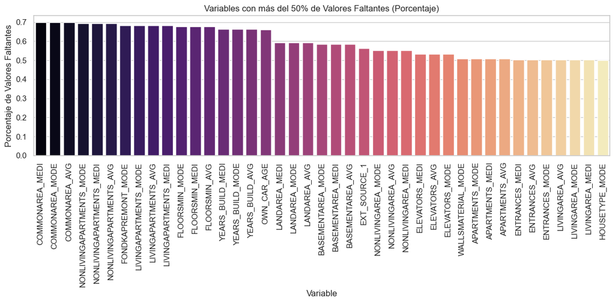

```python
# Crear un DataFrame para las variables con más del 50% de valores faltantes
variables_mas_nulos = columnas_a_eliminar.index
missing_data_treatment = pd.DataFrame({
    "Variable": variables_mas_nulos,
    "Porcentaje_Faltante": null_columns_df.loc[variables_mas_nulos, 'porcentaje_columnas']
}).reset_index(drop=True)

# Gráfico para visualizar las variables con más del 50% de valores faltantes
plt.figure(figsize=(12, 6))
sns.barplot(
    x="Variable",
    y="Porcentaje_Faltante",
    data=missing_data_treatment.sort_values(by="Porcentaje_Faltante", ascending=False),
    palette="magma"
)
plt.title("Variables con más del 50% de Valores Faltantes (Porcentaje)")
plt.ylabel("Porcentaje de Valores Faltantes")
plt.xticks(rotation=90)
plt.tight_layout()
plt.show()
```

**Eliminación de valores nulos según threshold**

Se aplicó un umbral del 50% tanto para columnas como para filas con valores nulos, obteniendo los siguientes resultados:

**Columnas eliminadas:**

Un total de 41 columnas fueron eliminadas del dataset, ya que más del 50% de sus valores eran nulos.

Entre las columnas eliminadas se encuentran COMMONAREA_MED, COMMONAREA_AVG y NONLIVINGAPARTMENTS_MODE, que presentaban un ~69% de valores faltantes. Estas variables probablemente contenían poca información útil debido a la gran cantidad de datos ausentes. Filas eliminadas:

No se eliminó ninguna fila, ya que ninguna fila superó el umbral del 50% de valores faltantes. Dimensiones del dataset:

Las dimensiones originales del dataset eran (307,511 filas x 122 columnas). Después de la limpieza, el dataset quedó reducido a (307,511 filas x 81 columnas), eliminando únicamente las columnas con demasiados valores nulos.

## **Identificar variables categóricas y numéricas**

```python
# Identificar variables categóricas y numéricas
categorical_vars = data_cleaned.select_dtypes(include=['object']).columns.tolist()
numerical_vars = data_cleaned.select_dtypes(include=['int64', 'float64']).columns.tolist()

print("Variables categóricas:")
print(categorical_vars)

print("\nVariables numéricas:")
print(numerical_vars)
```

```
Variables categóricas:
['NAME_CONTRACT_TYPE', 'CODE_GENDER', 'FLAG_OWN_CAR', 'FLAG_OWN_REALTY', 'NAME_TYPE_SUITE', 'NAME_INCOME_TYPE', 'NAME_EDUCATION_TYPE', 'NAME_FAMILY_STATUS', 'NAME_HOUSING_TYPE', 'OCCUPATION_TYPE', 'WEEKDAY_APPR_PROCESS_START', 'ORGANIZATION_TYPE', 'EMERGENCYSTATE_MODE']

Variables numéricas:
['SK_ID_CURR', 'TARGET', 'CNT_CHILDREN', 'AMT_INCOME_TOTAL', 'AMT_CREDIT', 'AMT_ANNUITY', 'AMT_GOODS_PRICE', 'REGION_POPULATION_RELATIVE', 'DAYS_BIRTH', 'DAYS_EMPLOYED', 'DAYS_REGISTRATION', 'DAYS_ID_PUBLISH', 'FLAG_MOBIL', 'FLAG_EMP_PHONE', 'FLAG_WORK_PHONE', 'FLAG_CONT_MOBILE', 'FLAG_PHONE', 'FLAG…
```

## **Convertir variables categóricas a tipo category**

```python
# Convertir variables categóricas a tipo 'category'
data_cleaned[categorical_vars] = data_cleaned[categorical_vars].astype('category')

# Verificar los tipos de datos después de la conversión
print("\nTipos de datos después de la conversión:")
print(data_cleaned[categorical_vars].dtypes)
```

```
Tipos de datos después de la conversión:
NAME_CONTRACT_TYPE            category
CODE_GENDER                   category
FLAG_OWN_CAR                  category
FLAG_OWN_REALTY               category
NAME_TYPE_SUITE               category
NAME_INCOME_TYPE              category
NAME_EDUCATION_TYPE           category
NAME_FAMILY_STATUS            category
NAME_HOUSING_TYPE             category
OCCUPATION_TYPE               category
WEEKDAY_APPR_PROCESS_START    category
ORGANIZATION_TYPE             category
EMERGENCYSTATE_MODE           category
dtype: object
```

## **Ver valores únicos en variables categóricas**

```python
# Ver valores únicos de cada variable categórica
for var in categorical_vars:
    print(f"\nValores únicos en la variable '{var}':")
    print(data_cleaned[var].value_counts())
```

```
Valores únicos en la variable 'NAME_CONTRACT_TYPE':
NAME_CONTRACT_TYPE
Cash loans         278232
Revolving loans     29279
Name: count, dtype: int64

Valores únicos en la variable 'CODE_GENDER':
CODE_GENDER
F      202448
M      105059
XNA         4
Name: count, dtype: int64

Valores únicos en la variable 'FLAG_OWN_CAR':
FLAG_OWN_CAR
N    202924
Y    104587
Name: count, dtype: int64

Valores únicos en la variable 'FLAG_OWN_REALTY':
FLAG_OWN_REALTY
Y    213312
N     94199
Name: count, dtype: int64

Valores únicos en la variable 'NAME_TYPE_SUITE':
NAME_TYPE_SUITE
Unaccompanied      248526
Family              40149
Spouse, partner     11370
Children             3267
Other_B              1770
Other_A               866
Group of people       271
Name: count, dtype: int64

Valores únicos en la variable 'NAME_INCOME_TYPE':
NAME_INCOME_TYPE
Working                 158774
Commercial associate     71617
```

[output cut: 122 more lines]

```
Transport: type 1           201
Industry: type 6            112
Industry: type 10           109
Religion                     85
Industry: type 13            67
Trade: type 4                64
Trade: type 5                49
Industry: type 8             24
Name: count, dtype: int64

Valores únicos en la variable 'EMERGENCYSTATE_MODE':
EMERGENCYSTATE_MODE
No     159428
Yes      2328
Name: count, dtype: int64
```

## **Tipos: Variables categóricas y numéricas**

```python
def plot_features(feature, label_rotation=False, horizontal_layout=True, figsize=(12, 12), font_scale=0.8, horizontal_bars=False, top_n=None, label_fontsize=8):
    # Estilo general
    sns.set_style("whitegrid")
    sns.set_context("talk", font_scale=font_scale)

    temp = data[feature].value_counts()
    df1 = pd.DataFrame({feature: temp.index, 'valores absolutos': temp.values})

    t1_percentage = data[[feature, 'TARGET']].groupby([feature], as_index=False).mean()
    t1_percentage.sort_values(by='TARGET', ascending=False, inplace=True)

    # Si top_n está definido, selecciona las principales categorías
    if top_n:
        df1 = df1.head(top_n)
        t1_percentage = t1_percentage.head(top_n)

    if horizontal_bars:
        figsize = (figsize[1], figsize[0])

    if horizontal_layout:
        fig, (ax1, ax2) = plt.subplots(ncols=2, figsize=figsize)
    else:
        fig, (ax1, ax2) = plt.subplots(nrows=2, figsize=figsize)

    # Colores
    custom_palette1 = sns.color_palette("pastel")
    custom_palette2 = sns.color_palette("coolwarm", len(t1_percentage))

    # Gráfico 1: Valores absolutos
    if horizontal_bars:
        s1 = sns.barplot(
            ax=ax1,
            y=feature,
            x="valores absolutos",
            data=df1,
            palette=custom_palette1
        )
        ax1.set_ylabel(feature, fontsize=label_fontsize)
        ax1.set_xlabel("Frecuencia Absoluta", fontsize=label_fontsize)
        ax1.tick_params(axis='y', labelsize=label_fontsize)
    else:
        s1 = sns.barplot(
            ax=ax1,
            x=feature,
            y="valores absolutos",
            data=df1,
            palette=custom_palette1
        )
        ax1.set_xlabel(feature, fontsize=label_fontsize)
        ax1.set_ylabel("Frecuencia Absoluta", fontsize=label_fontsize)
        ax1.tick_params(axis='x', labelsize=label_fontsize)

    ax1.set_title(f"Distribución de {feature}", fontsize=label_fontsize)
    if label_rotation:
        s1.set_xticklabels(s1.get_xticklabels(), rotation=90, fontsize=label_fontsize)

    # Gráfico 2: Porcentaje de 'TARGET'
    if horizontal_bars:
        s2 = sns.barplot(
            ax=ax2,
            y=feature,
            x="TARGET",
            order=t1_percentage[feature],
            data=t1_percentage,
            palette=custom_palette2
        )
        ax2.set_ylabel(feature, fontsize=label_fontsize)
        ax2.set_xlabel("% No Devueltos", fontsize=label_fontsize)
        ax2.tick_params(axis='y', labelsize=label_fontsize)
    else:
        s2 = sns.barplot(
            ax=ax2,
            x=feature,
            y="TARGET",
            order=t1_percentage[feature],
            data=t1_percentage,
            palette=custom_palette2
        )
        ax2.set_xlabel(feature, fontsize=label_fontsize)
        ax2.set_ylabel("% No Devueltos", fontsize=label_fontsize)
        ax2.tick_params(axis='x', labelsize=label_fontsize)

    ax2.set_title(f"% No Devueltos por {feature}", fontsize=label_fontsize)
    if label_rotation:
        s2.set_xticklabels(s2.get_xticklabels(), rotation=90, fontsize=label_fontsize)

    # Ajustes finales
    plt.subplots_adjust(wspace=0.4, hspace=0.4)
    plt.show()
```

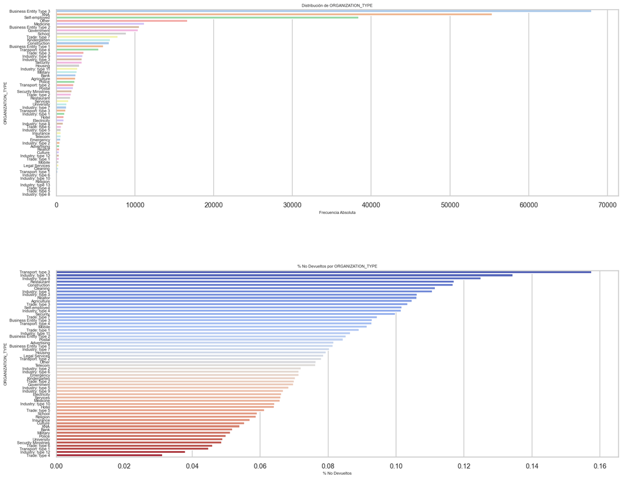

```python
plot_features('ORGANIZATION_TYPE', label_rotation=False, horizontal_layout=False, figsize=(16, 20), horizontal_bars=True)
```

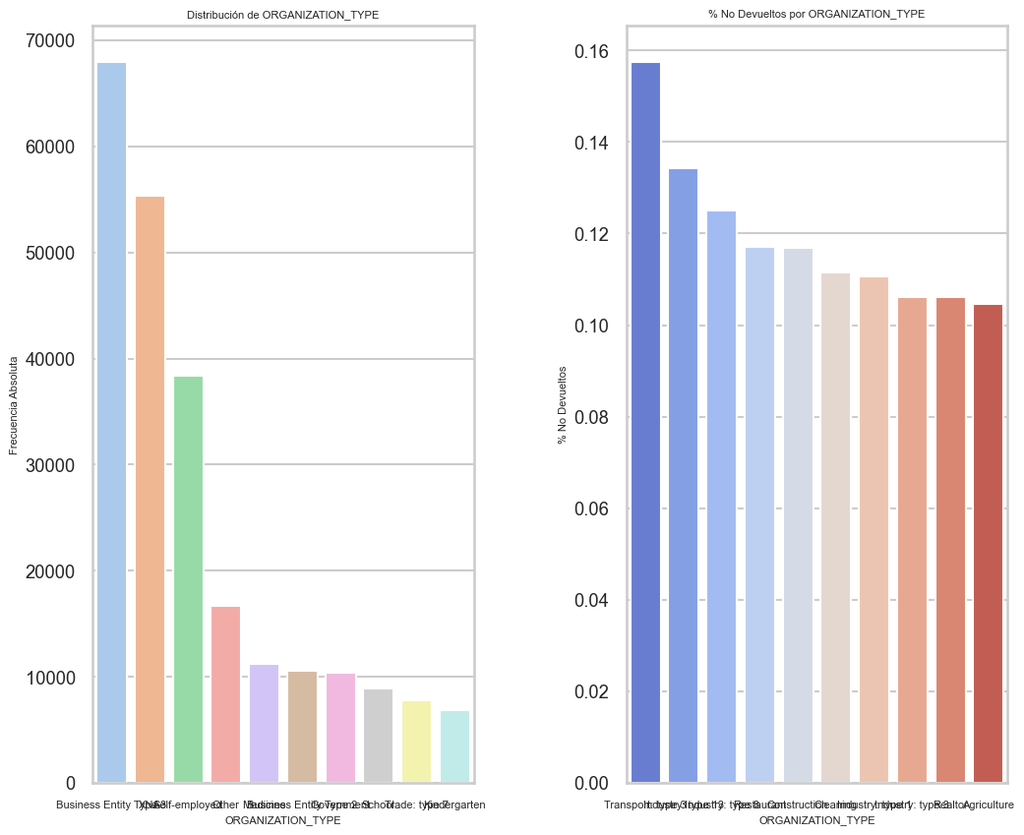

```python
plot_features('ORGANIZATION_TYPE', label_rotation=False, horizontal_layout=True, figsize=(12, 10), top_n=10)
```

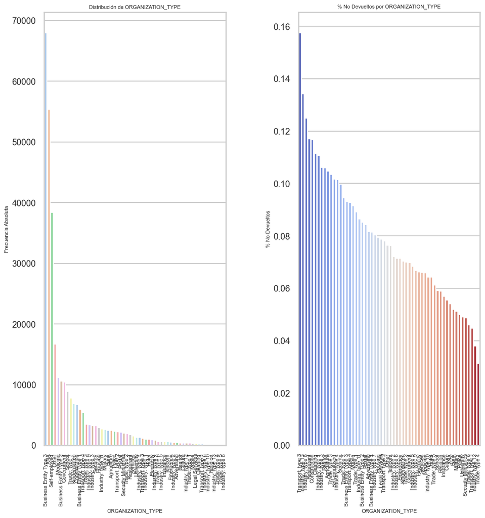

```python
plot_features('ORGANIZATION_TYPE',True,True)
```

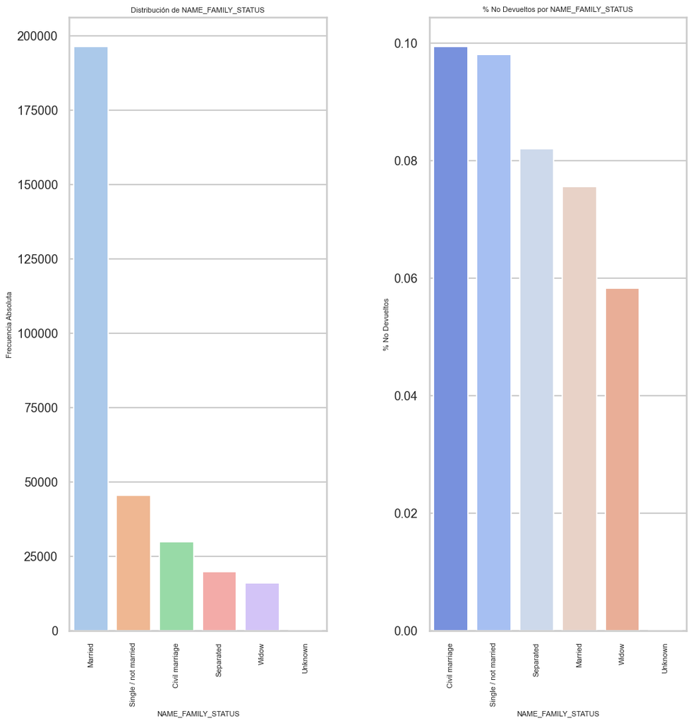

```python
plot_features('NAME_FAMILY_STATUS',True,True)
```

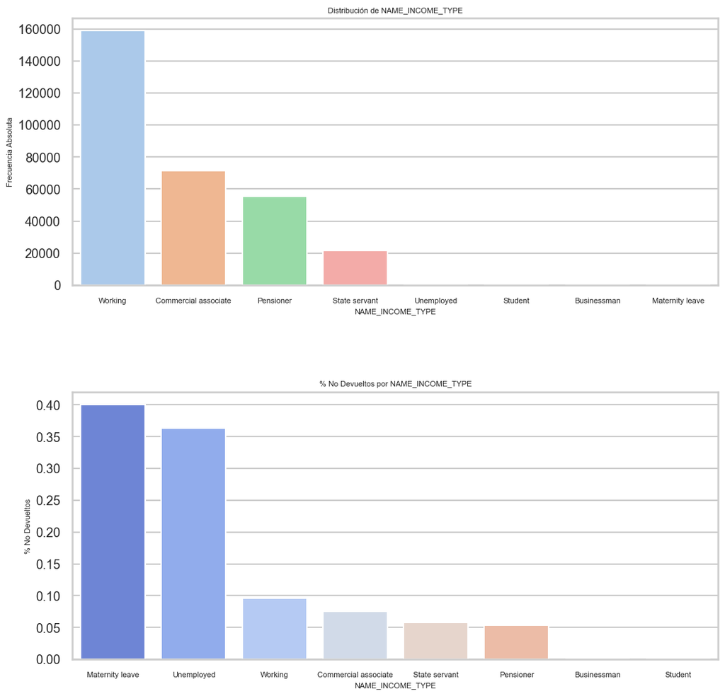

```python
plot_features('NAME_INCOME_TYPE',False,False)
```

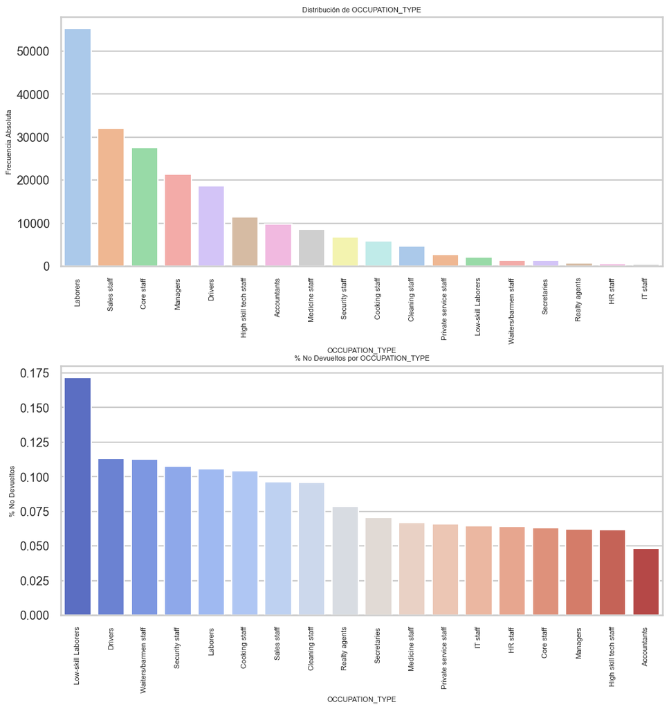

```python
plot_features('OCCUPATION_TYPE',True,False)
```

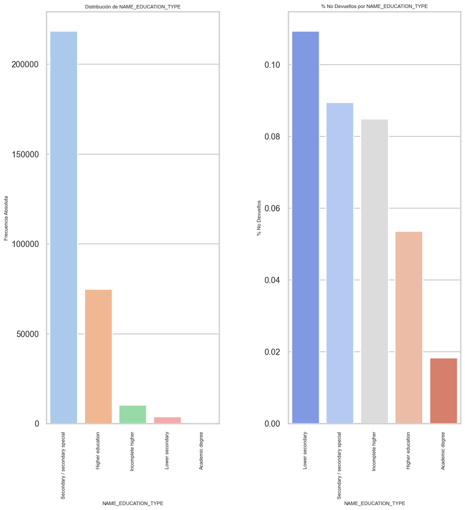

```python
plot_features('NAME_EDUCATION_TYPE',True,True)
```

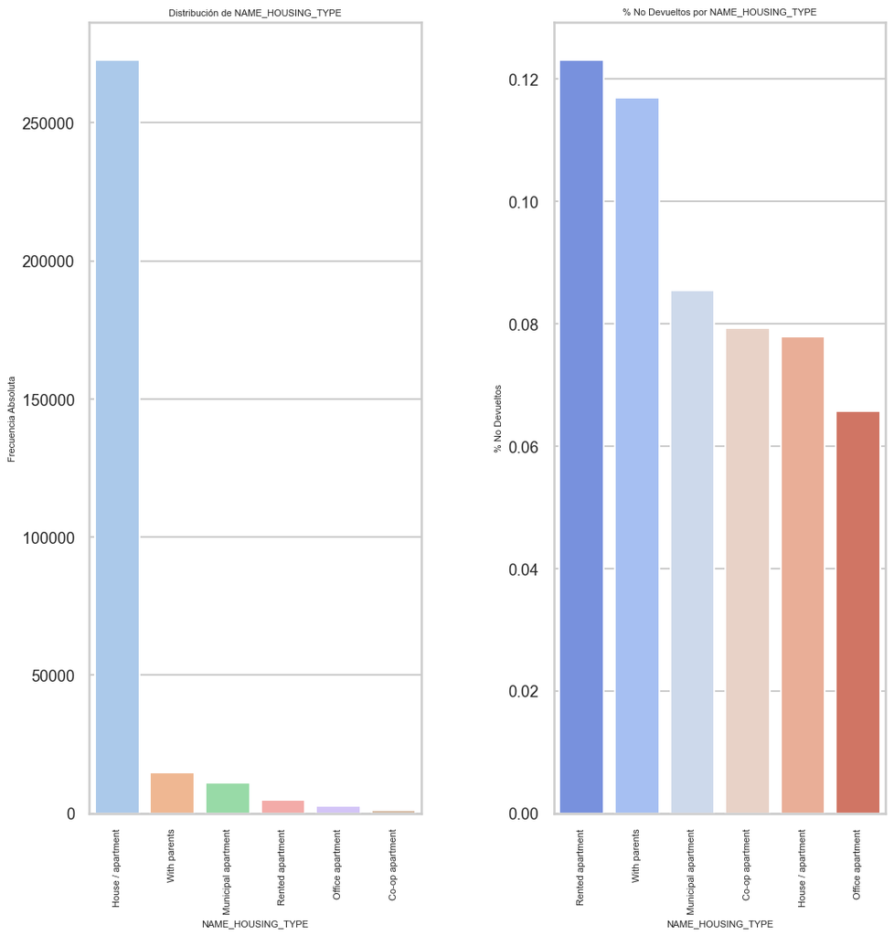

```python
plot_features('NAME_HOUSING_TYPE',True,True)
```

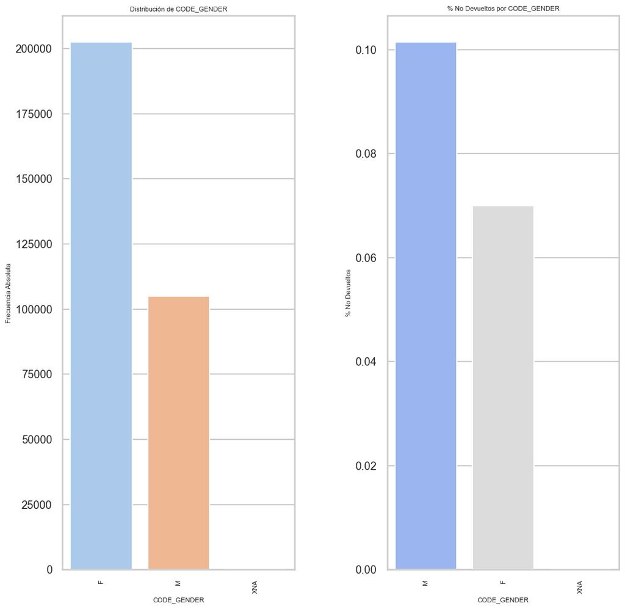

```python
plot_features('CODE_GENDER',True,True)
```

### *Explicaciones de cada gráfico para incluir en tu informe*

#### *Gráfico 4: Distribución de OCCUPATION_TYPE*

Este gráfico muestra la cantidad de préstamos según la ocupación de los clientes:

- Los “Laborers” representan el grupo con mayor número de solicitudes, seguidos de “Sales staff”.
- Las ocupaciones de baja cualificación, como “Low-skill laborers”, tienen las mayores tasas de incumplimiento.
- La ocupación indica el nivel de ingresos y la estabilidad laboral, lo que influye directamente en la capacidad de pago.

#### *Gráfico 5: Distribución de NAME_EDUCATION_TYPE*

La gráfica representa los niveles educativos de los clientes:

- La mayoría de los clientes tiene educación secundaria o secundaria especial (~71%), seguida de educación superior (~24%).
- Los niveles educativos más bajos, como educación secundaria incompleta, presentan las mayores tasas de incumplimiento.
- El nivel educativo está correlacionado con el acceso a mejores oportunidades laborales y financieras, lo que lo convierte en un indicador relevante de riesgo.

#### *Gráfico 6: Distribución de NAME_HOUSING_TYPE*

El gráfico muestra la cantidad de préstamos según el tipo de vivienda:

- La mayoría de los clientes vive en casa o apartamento propio (~88%), seguido de los que viven con sus padres o en apartamentos alquilados.
- Las personas que viven en apartamentos alquilados presentan las mayores tasas de incumplimiento.
- El tipo de vivienda puede ser un reflejo de la estabilidad financiera de los clientes y de su capacidad para asumir compromisos financieros a largo plazo.

#### *Gráfico 7: Distribución de CODE_GENDER*

1. *Relación directa con el incumplimiento:* Cada variable seleccionada tiene un impacto potencial en la capacidad del cliente para cumplir con los pagos del préstamo.
2. *Segmentación efectiva:* Los gráficos permiten identificar grupos específicos con mayor riesgo de incumplimiento.
3. *Relevancia sociodemográfica y económica:* Factores como género, ocupación, nivel educativo y tipo de vivienda son determinantes clave en el análisis de crédito.
4. *Optimización del modelo predictivo:* Incluir estas variables en el análisis ayuda a construir un modelo más robusto que puede predecir mejor el comportamiento de los clientes.

A continuación, calculamos el porcentaje de desbalance, ya que la mayoría corresponde a la clase target0 y la minoría a la clase target1

```
Imbalance Percentage: 8.78%
```

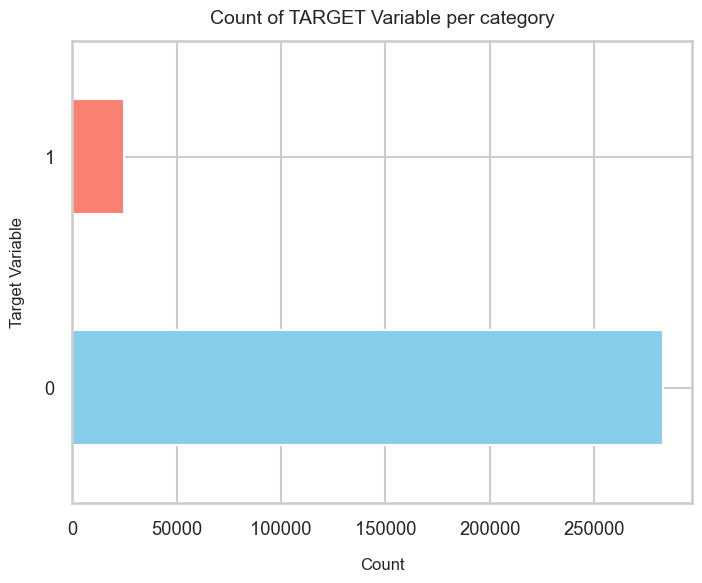

```python
# Calculamos el conteo de cada categoría en la variable TARGET
target_counts = data['TARGET'].value_counts()

# Calculamos el porcentaje de desbalance
imbalance_percentage = (target_counts.min() / target_counts.max()) * 100
print(f"Imbalance Percentage: {imbalance_percentage:.2f}%")

# Graficamos el conteo de la variable TARGET
target_counts.plot(kind='barh', figsize=(8, 6), color=['skyblue', 'salmon'])
plt.xlabel("Count", labelpad=14, fontsize=12)
plt.ylabel("Target Variable", labelpad=14, fontsize=12)
plt.title("Count of TARGET Variable per category", y=1.02, fontsize=14)
plt.show()
```

```python
# Función para filtrar y graficar

def plot_by_target(df, col, target_value, hue=None, log_scale=False, rotation=45, palette='bright'):
    # Filtrar el dataframe para el valor de TARGET deseado
    filtered_df = df[df['TARGET'] == target_value]

    # Título dinámico según el valor de TARGET
    title = f"Distribution of {col} - For Target: {target_value}"

    # Graficar con seaborn
    plt.figure(figsize=(10, 6))
    sns.countplot(data=filtered_df, x=col, hue=hue, palette=palette)
    plt.title(title)
    plt.xticks(rotation=rotation)
    plt.show()
```

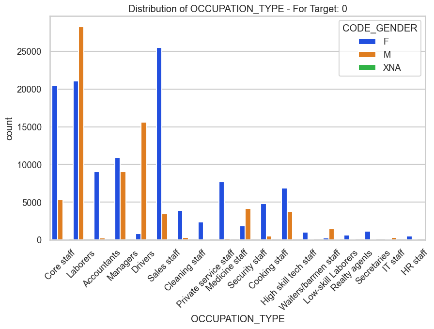

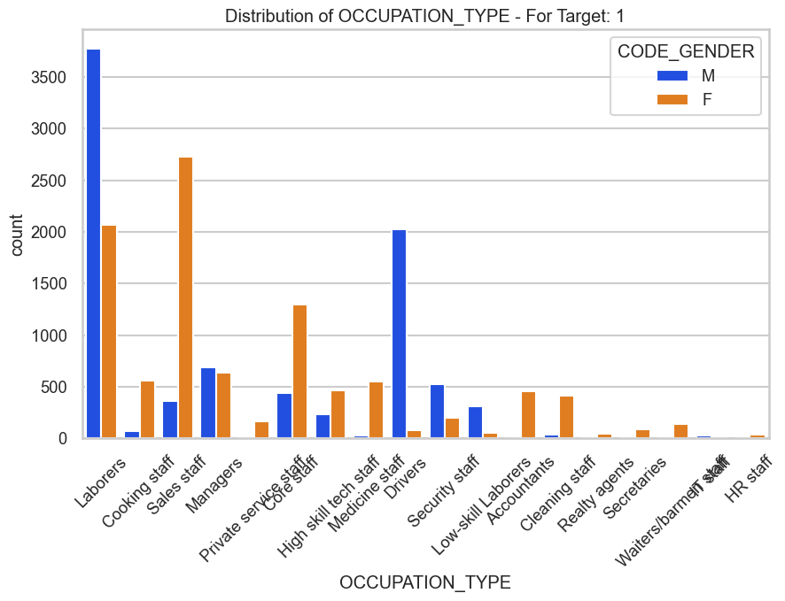

```python
# Distribución de la columna 'OCCUPATION_TYPE' cuando TARGET es 0
plot_by_target(data, col='OCCUPATION_TYPE', target_value=0, hue='CODE_GENDER', log_scale=False)

# Distribución de la columna 'OCCUPATION_TYPE' cuando TARGET es 1
plot_by_target(data, col='OCCUPATION_TYPE', target_value=1, hue='CODE_GENDER', log_scale=False)
```

# Análisis de Género vs Tipo de Ocupación en relación con la Variable Target

### Puntos clave:

1. **Mujeres:**
   - Las mujeres que trabajan como **contables**, personal de servicio privado, personal de cocina, personal de recursos humanos, entre otros, tienen una mayor tasa de incumplimiento (**default**) en comparación con los hombres en estas mismas ocupaciones.
2. **Hombres:**
   - Los hombres que trabajan en ocupaciones como **mano de obra de baja calificación** o **conductores** tienen una mayor tasa de incumplimiento en comparación con las mujeres en estas mismas ocupaciones.

### Conclusiones:

- **Conclusión 1:**
  - Las mujeres en ocupaciones como:
    - **Contables**
    - **Personal de servicio privado**
    - **Secretarias**
    - **Agentes inmobiliarios**
    - **Recursos humanos**
  - Son las que más incumplen en comparación con los hombres en estas profesiones.
- **Conclusión 2:**
  - Los hombres en ocupaciones como:
    - **Mano de obra de baja calificación**
    - **Conductores**
  - Destacan como los que más incumplen en comparación con las mujeres en estos roles.

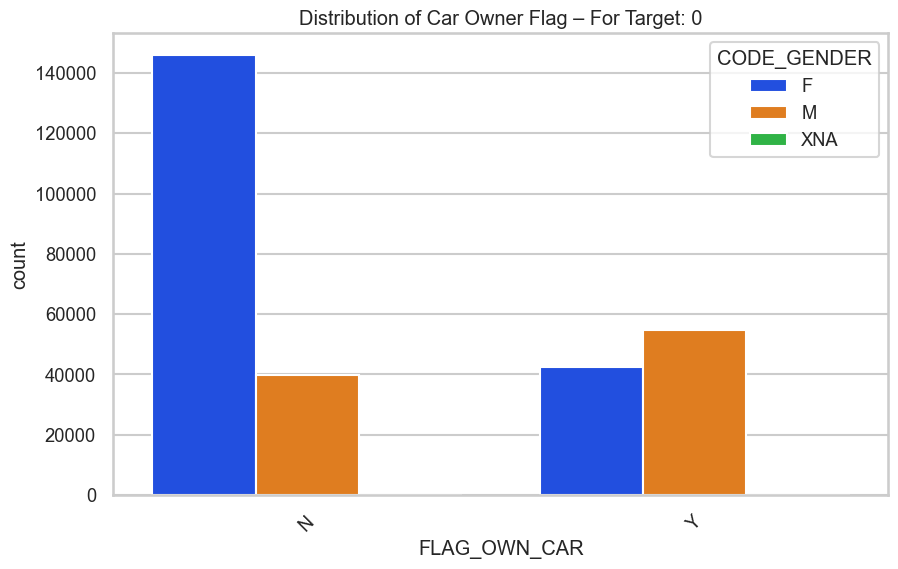

```python
# Filtrar el dataset para TARGET=0
target0_df = data[data['TARGET'] == 0]

# Crear el gráfico usando seaborn
plt.figure(figsize=(10, 6))
sns.countplot(data=target0_df, x='FLAG_OWN_CAR', hue='CODE_GENDER', palette='bright')
plt.title('Distribution of Car Owner Flag – For Target: 0')
plt.xticks(rotation=45)
plt.show()
```

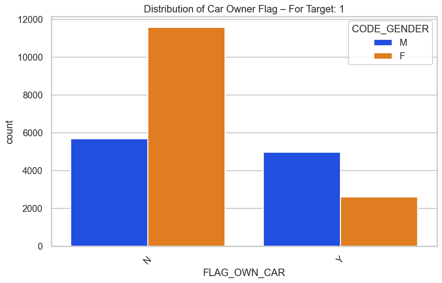

```python
# Filtrar el dataset para TARGET=1
target1_df = data[data['TARGET'] == 1]

# Crear el gráfico usando seaborn
plt.figure(figsize=(10, 6))
sns.countplot(data=target1_df, x='FLAG_OWN_CAR', hue='CODE_GENDER', palette='bright')
plt.title('Distribution of Car Owner Flag – For Target: 1')
plt.xticks(rotation=45)
plt.show()
```

### Análisis de Propiedad de Vehículo en Relación con los Incumplimientos

- **Insight general:** En términos generales, las personas que **no poseen coche** son las que tienen mayor tasa de incumplimiento.
- **Insight específico:** Al profundizar en el análisis, se observa que las **mujeres sin coche** son las que más incumplen en comparación con los hombres que tampoco poseen coche.

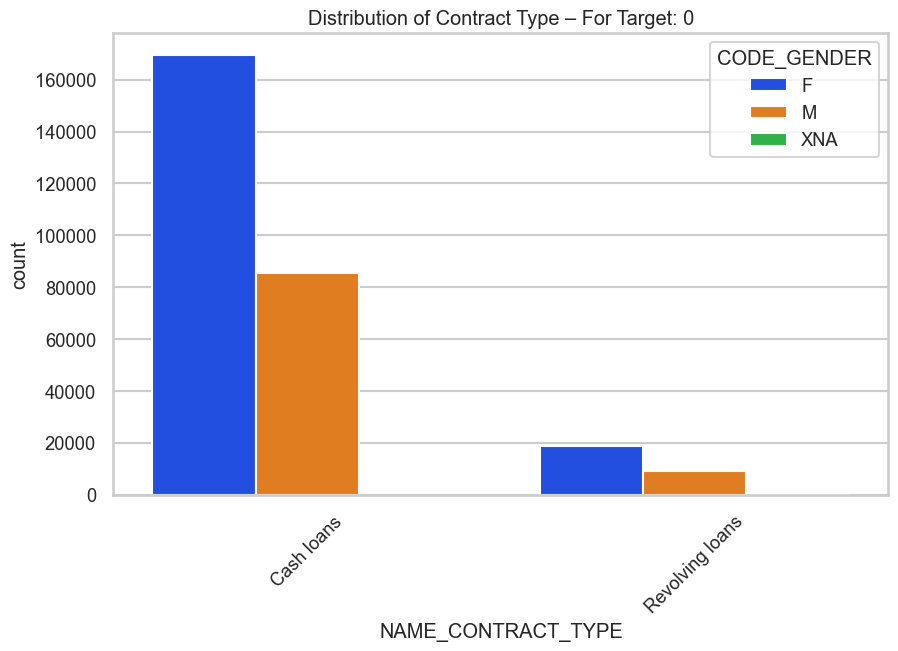

```python
# Filtrar el dataset para TARGET=0
target0_df = data[data['TARGET'] == 0]

# Crear el gráfico usando seaborn
plt.figure(figsize=(10, 6))
sns.countplot(data=target0_df, x='NAME_CONTRACT_TYPE', hue='CODE_GENDER', palette='bright')
plt.title('Distribution of Contract Type – For Target: 0')
plt.xticks(rotation=45)
plt.show()
```

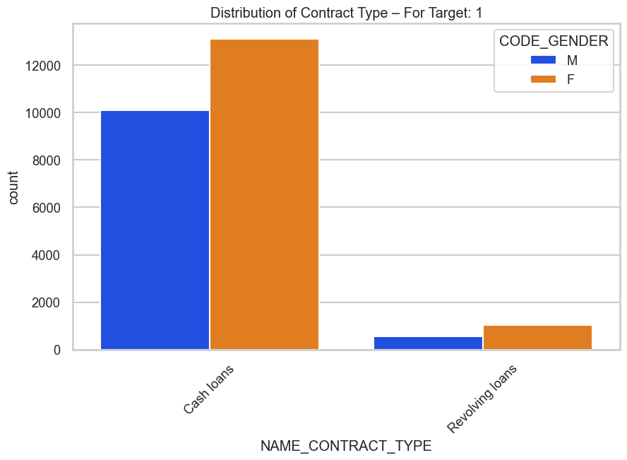

```python
# Filtrar el dataset para TARGET=1
target1_df = data[data['TARGET'] == 1]

# Crear el gráfico usando seaborn
plt.figure(figsize=(10, 6))
sns.countplot(data=target1_df, x='NAME_CONTRACT_TYPE', hue='CODE_GENDER', palette='bright')
plt.title('Distribution of Contract Type – For Target: 1')
plt.xticks(rotation=45)
plt.show()
```

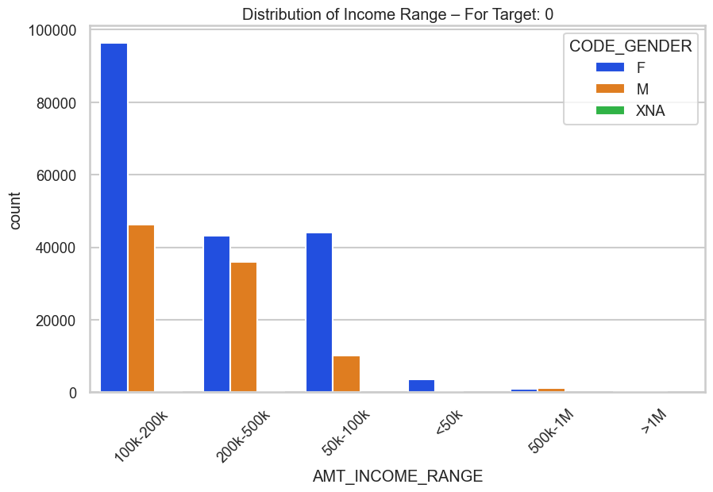

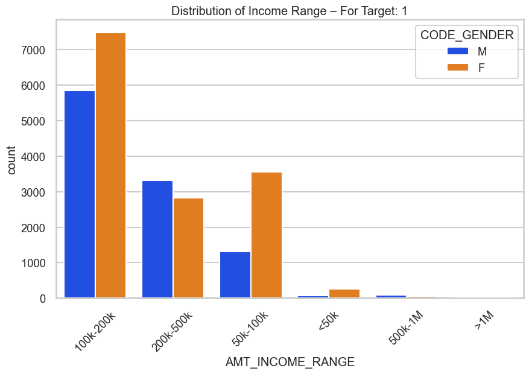

```python
# Crear una nueva columna agrupando AMT_INCOME_TOTAL en rangos
bins = [0, 50000, 100000, 200000, 500000, 1000000, data['AMT_INCOME_TOTAL'].max()]
labels = ['<50k', '50k-100k', '100k-200k', '200k-500k', '500k-1M', '>1M']
data['AMT_INCOME_RANGE'] = pd.cut(data['AMT_INCOME_TOTAL'], bins=bins, labels=labels)

# Filtrar los datasets para TARGET=0 y TARGET=1
target0_df = data[data['TARGET'] == 0]
target1_df = data[data['TARGET'] == 1]

# Ordenar las categorías por recuento para TARGET=0
order_target0 = (
    target0_df['AMT_INCOME_RANGE']
    .value_counts()
    .sort_values(ascending=False)
    .index
)

# Crear el gráfico para TARGET=0
plt.figure(figsize=(10, 6))
sns.countplot(
    data=target0_df,
    x='AMT_INCOME_RANGE',
    hue='CODE_GENDER',
    palette='bright',
    order=order_target0
)
plt.title('Distribution of Income Range – For Target: 0')
plt.xticks(rotation=45)
plt.show()

# Ordenar las categorías por recuento para TARGET=1
order_target1 = (
    target1_df['AMT_INCOME_RANGE']
    .value_counts()
    .sort_values(ascending=False)
    .index
)

# Crear el gráfico para TARGET=1
plt.figure(figsize=(10, 6))
sns.countplot(
    data=target1_df,
    x='AMT_INCOME_RANGE',
    hue='CODE_GENDER',
    palette='bright',
    order=order_target1
)
plt.title('Distribution of Income Range – For Target: 1')
plt.xticks(rotation=45)
plt.show()
```

#### Análisis de Rango de Ingresos en Relación con la Variable Target

**Distribución para TARGET = 0**

**Insights Generales:**

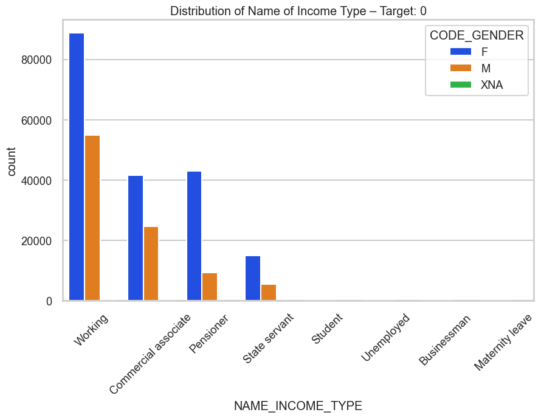

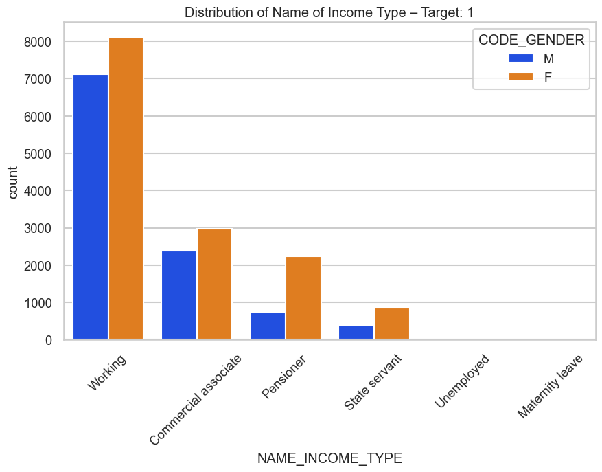

```python
# Filtrar el dataset para TARGET=0 y TARGET=1
target0_df = data[data['TARGET'] == 0]
target1_df = data[data['TARGET'] == 1]

# Ordenar categorías por recuento para TARGET=0
order_target0 = (
    target0_df['NAME_INCOME_TYPE']
    .value_counts()
    .sort_values(ascending=False)
    .index
)

# Ordenar categorías por recuento para TARGET=1
order_target1 = (
    target1_df['NAME_INCOME_TYPE']
    .value_counts()
    .sort_values(ascending=False)
    .index
)

# Gráfico para TARGET=0
plt.figure(figsize=(10, 6))
sns.countplot(
    data=target0_df,
    x='NAME_INCOME_TYPE',
    hue='CODE_GENDER',
    palette='bright',
    order=order_target0
)
plt.title('Distribution of Name of Income Type – Target: 0')
plt.xticks(rotation=45)
plt.show()

# Gráfico para TARGET=1
plt.figure(figsize=(10, 6))
sns.countplot(
    data=target1_df,
    x='NAME_INCOME_TYPE',
    hue='CODE_GENDER',
    palette='bright',
    order=order_target1
)
plt.title('Distribution of Name of Income Type – Target: 1')
plt.xticks(rotation=45)
plt.show()
```

### Análisis del Tipo de Ingreso en Relación con la Variable Target

**Insights Generales:**

1. Para los tipos de ingreso **‘Working’**, **‘Commercial Associate’** , **‘State Servant’** y **‘Pensioner’** el número de créditos es mayor en comparación con otros tipos como **‘Maternity Leave’**.
2. En estos grupos, las **mujeres** tienen un número significativamente mayor de créditos en comparación con los hombres.

   **Insights Específicos para TARGET = 1 (Incumplidores):**
3. No hay registros de incumplimiento para los tipos de ingreso **‘Student’** y **‘Businessman’**, lo que indica que estas personas no realizan pagos tardíos.
4. Los incumplimientos son más comunes en profesionales **‘Working’**, **‘Commercial Associate’** , **‘State Servant’** y **‘Pensioner’**.

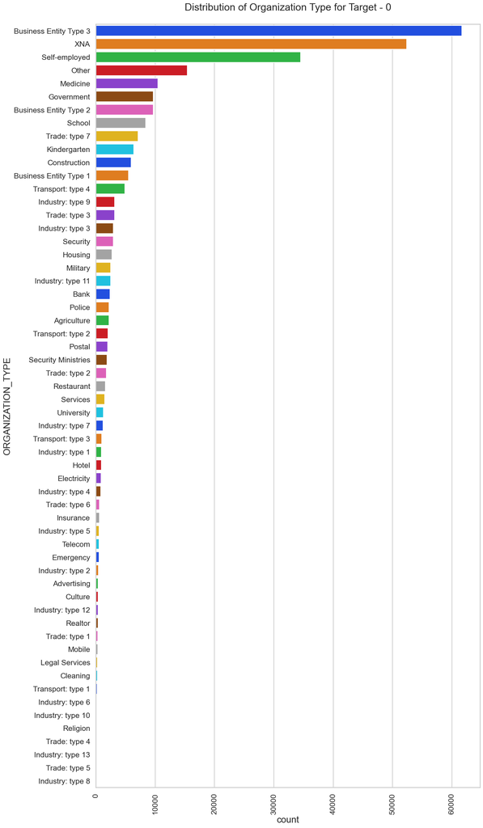

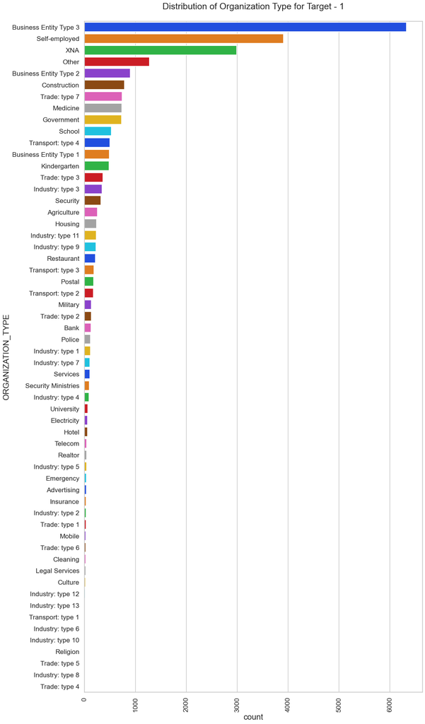

```python
# Gráfico para TARGET=0
sns.set_style('whitegrid')
sns.set_context('talk')
plt.figure(figsize=(15, 30))
plt.rcParams["axes.labelsize"] = 20
plt.rcParams['axes.titlesize'] = 22
plt.rcParams['axes.titlepad'] = 30

plt.title("Distribution of Organization Type for Target - 0")
plt.xticks(rotation=90)

# Aplicar orden correcto en base a conteos y sin usar escala logarítmica en el eje x
sns.countplot(
    data=target0_df,
    y='ORGANIZATION_TYPE',
    order=target0_df['ORGANIZATION_TYPE'].value_counts().index,
    palette='bright'
)

plt.xscale('linear')  # Eliminar escala logarítmica en x si no es necesaria
plt.show()

# Gráfico para TARGET=1
sns.set_style('whitegrid')
sns.set_context('talk')
plt.figure(figsize=(15, 30))
plt.rcParams["axes.labelsize"] = 20
plt.rcParams['axes.titlesize'] = 22
plt.rcParams['axes.titlepad'] = 30

plt.title("Distribution of Organization Type for Target - 1")
plt.xticks(rotation=90)

# Aplicar orden correcto en base a conteos y evitar escala logarítmica en x
sns.countplot(
    data=target1_df,
    y='ORGANIZATION_TYPE',
    order=target1_df['ORGANIZATION_TYPE'].value_counts().index,
    palette='bright'
)

plt.xscale('linear')  # Escala estándar para barras categóricas
plt.show()
```

#### Análisis del Tipo de Organización para Clientes que Solicitan Créditos

**Puntos Clave:**

1. La mayoría de los clientes que han solicitado créditos provienen de los tipos de organización:
   - **‘Business Entity Type 3’**
   - **‘Self Employed’**
   - **‘Other’**
   - **‘Medicine’**
   - **‘Government’**
2. Hay menos clientes provenientes de los siguientes tipos de industria:
   - **Industry Type 8**
   - **Industry Type 6**
   - **Industry Type 10**
   - **Religion**
   - **Trade Type 5**
   - **Trade Type 4**

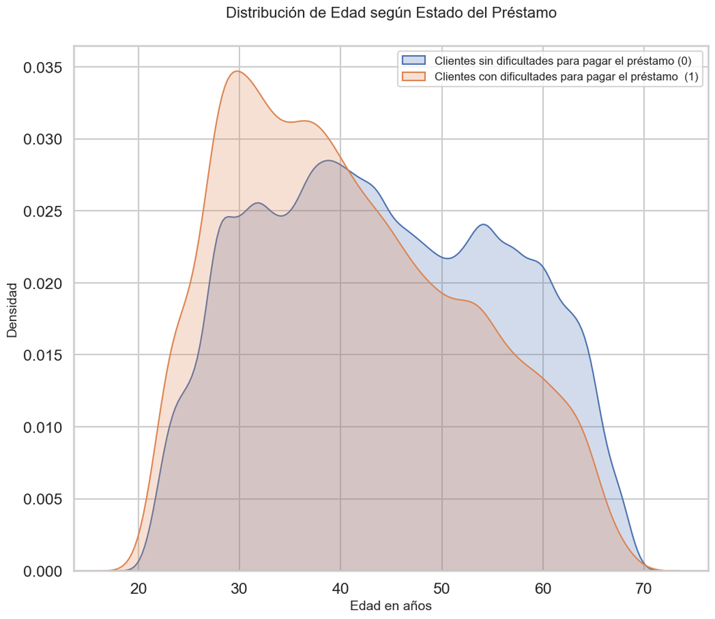

```python
plt.figure(figsize=(12, 10))

# Graficar la distribución de edades para TARGET=0 (préstamos no incumplidos)
sns.kdeplot(
    data.loc[data['TARGET'] == 0, 'DAYS_BIRTH'] / -365,
    label='Clientes sin dificultades para pagar el préstamo (0)',
    shade=True
)

# Graficar la distribución de edades para TARGET=1 (préstamos incumplidos)
sns.kdeplot(
    data.loc[data['TARGET'] == 1, 'DAYS_BIRTH'] / -365,
    label='Clientes con dificultades para pagar el préstamo  (1)',
    shade=True
)

# Etiquetas y título
plt.xlabel('Edad en años', fontsize=14)
plt.ylabel('Densidad', fontsize=14)
plt.title('Distribución de Edad según Estado del Préstamo', fontsize=16)
plt.legend(fontsize=12)
plt.show()
```

#### Análisis de la Relación entre Edad y Reembolso de Préstamos

1. A medida que los clientes son **más mayores**, tienden a **tener menos dificultades** para cumplir con sus responsabilidades crediticias.
2. Los clientes **más jóvenes** son menos fiables en comparación con los clientes mayores.

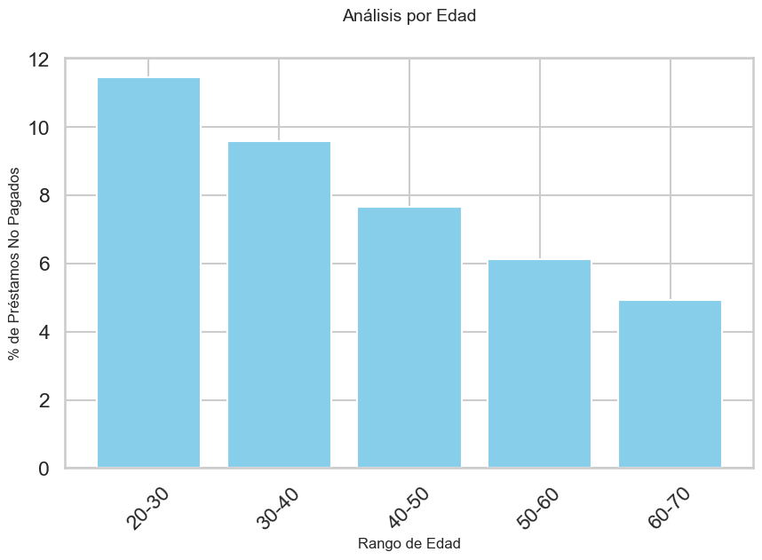

```python
# Crear rangos de edad (en años)
data['AGE'] = (data['DAYS_BIRTH'] / -365).astype(int)
age_bins = [20, 30, 40, 50, 60, 70, 80]
age_labels = ['20-30', '30-40', '40-50', '50-60', '60-70', '70-80']
data['AGE_RANGE'] = pd.cut(data['AGE'], bins=age_bins, labels=age_labels, right=False)

# Calcular el porcentaje de préstamos no pagados por rango de edad
age_data = data.groupby('AGE_RANGE')['TARGET'].mean() * 100

# Graficar
plt.figure(figsize=(10, 6))
plt.bar(age_data.index.astype(str), age_data, color='skyblue')
plt.xticks(rotation=45)
plt.xlabel('Rango de Edad', fontsize=12)
plt.ylabel('% de Préstamos No Pagados', fontsize=12)
plt.title('Análisis por Edad', fontsize=14)
plt.show()
```

#### Análisis del Gráfico de Edad y Tasa de Incumplimiento

- Este gráfico es consistente con el análisis anterior:
  - Los clientes **jóvenes** tienen una tasa de incumplimiento de aproximadamente del **12%**.
  - Los clientes **mayores** tienen una tasa significativamente menor, de solo **5%**.

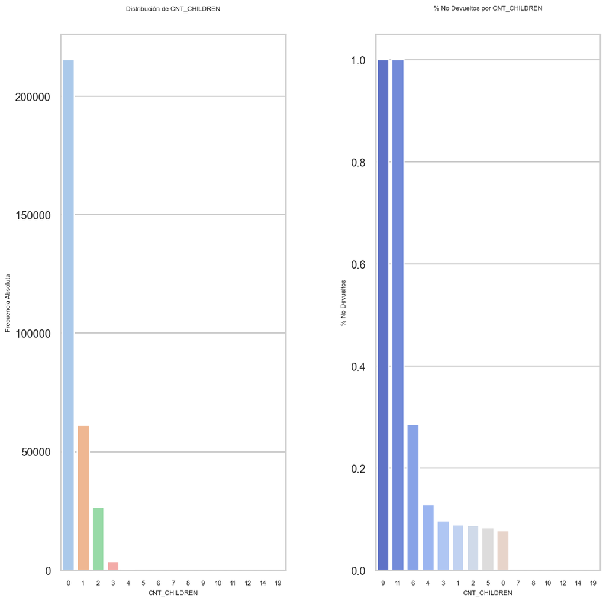

```python
def plot_numerical(feature):
    """
    Función para graficar la distribución de una variable numérica.
    :param feature: Nombre de la columna en el dataset
    """
    plt.figure(figsize=(10, 6))
    plt.title(f"Distribución de {feature}", fontsize=16)

    # Graficar la distribución
    sns.histplot(data[feature].dropna(), kde=True, bins=30, color='skyblue', edgecolor='black')

    # Etiquetas de los ejes
    plt.xlabel(feature, fontsize=12)
    plt.ylabel("Frecuencia", fontsize=12)
    plt.show()

# Ejemplo de uso con tu dataset

plot_features('CNT_CHILDREN')
```

En un principio pensamos que el número de hijos, sería una variable significativa en el análisis de la calidad crediticia de los clientes. Pero el gráfico de la derecha, demuestra que no es así ya que, aquellos individuos que tienen mas problemas, aun siendo estos muy pocos (menos de 1%), a la hora de pagar los créditos son los individuos con 9 u 11 hijos, los cuales son una minoría (prácticamente insignificante) y no tienen un impacto directo sobre la variable objetivo.

[figure not shown]

[figure not shown]

```python
def plot_comparisons(features):
    """
    Función para comparar la distribución de múltiples variables numéricas
    entre clientes que pagaron el préstamo (TARGET=0) y los que no lo hicieron (TARGET=1).

    :param features: Lista de columnas numéricas a comparar.
    """
    # Filtrar los datos según el valor de TARGET
    t_1 = data.loc[data['TARGET'] == 1]
    t_0 = data.loc[data['TARGET'] == 0]

    for feature in features:
        plt.figure(figsize=(12, 6))

        # Graficar la distribución para TARGET=0 y TARGET=1
        sns.kdeplot(
            t_0[feature].dropna(),
            bw_adjust=0.5,
            label="Clientes con dificultades para pagar el préstamo",
            shade=True,
            color="skyblue"
        )
        sns.kdeplot(
            t_1[feature].dropna(),
            bw_adjust=0.5,
            label="Clientes sin dificultades para pagar el préstamo",
            shade=True,
            color="salmon"
        )

        # Configuración del gráfico
        plt.title(f"Comparación de {feature}", fontsize=16)
        plt.ylabel('Densidad', fontsize=12)
        plt.xlabel(feature, fontsize=12)
        plt.legend(fontsize=12)
        plt.tick_params(axis='both', which='major', labelsize=10)
        plt.grid(True, linestyle='--', alpha=0.5)

    plt.show()

# Lista de características a comparar
feat = ['AMT_CREDIT', 'AMT_ANNUITY']

# Llamar a la función con el dataset
plot_comparisons(feat)
```

#### Análisis de los gráficos

[output not shown]

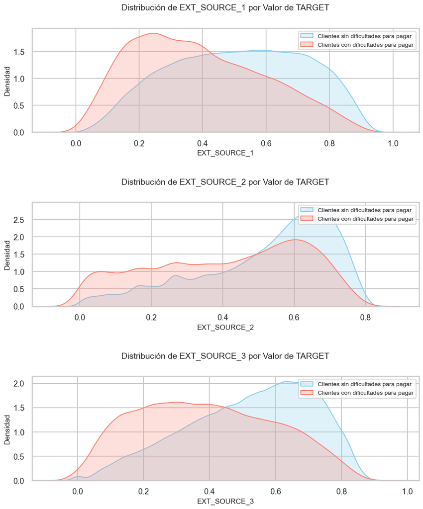

```python
plt.figure(figsize=(10, 12))

# Lista de fuentes externas
externals = ['EXT_SOURCE_1', 'EXT_SOURCE_2', 'EXT_SOURCE_3']

# Generar gráficos para cada fuente externa
for i, source in enumerate(externals):
    plt.subplot(3, 1, i + 1)

    # Distribución para TARGET=0
    sns.kdeplot(
        data.loc[data['TARGET'] == 0, source],
        label='Clientes sin dificultades para pagar',
        shade=True,
        color='skyblue'
    )

    # Distribución para TARGET=1
    sns.kdeplot(
        data.loc[data['TARGET'] == 1, source],
        label='Clientes con dificultades para pagar',
        shade=True,
        color='salmon'
    )

    # Configuración del gráfico
    plt.title(f'Distribución de {source} por Valor de TARGET', fontsize=14)
    plt.xlabel(f'{source}', fontsize=12)
    plt.ylabel('Densidad', fontsize=12)
    plt.legend(fontsize=10)

# Ajustar el espaciado entre los subgráficos
plt.tight_layout(h_pad=2.5)
plt.show()
```

Son variables que tienen un impacto significativo a la hora de analizar la variable objetivo, pero desconocemos el tipo de informacion que contienen estos datos, por lo que no se puede llegar a una conclusión concreta acerca de la relevancia en el modelo.

## **Analizar variables numéricas**

```python
# Describir estadísticas de variables numéricas
print("\nEstadísticas descriptivas de las variables numéricas:")
print(data_cleaned[numerical_vars].describe())
```

```
Estadísticas descriptivas de las variables numéricas:
          SK_ID_CURR         TARGET   CNT_CHILDREN  AMT_INCOME_TOTAL  \
count  307511.000000  307511.000000  307511.000000      3.075110e+05
mean   278180.518577       0.080729       0.417052      1.687979e+05
std    102790.175348       0.272419       0.722121      2.371231e+05
min    100002.000000       0.000000       0.000000      2.565000e+04
25%    189145.500000       0.000000       0.000000      1.125000e+05
50%    278202.000000       0.000000       0.000000      1.471500e+05
75%    367142.500000       0.000000       1.000000      2.025000e+05
max    456255.000000       1.000000      19.000000      1.170000e+08

         AMT_CREDIT    AMT_ANNUITY  AMT_GOODS_PRICE  \
count  3.075110e+05  307499.000000     3.072330e+05
mean   5.990260e+05   27108.573909     5.383962e+05
std    4.024908e+05   14493.737315     3.694465e+05
min    4.500000e+04    1615.500000     4.050000e+04
25%    2.700000e+05   16524.000000     2.385000e+05
50%    5.135310e+05   24903.000000     4.500000e+05
75%    8.086500e+05   34596.000000     6.795000e+05
max    4.050000e+06  258025.500000     4.050000e+06

       REGION_POPULATION_RELATIVE     DAYS_BIRTH  DAYS_EMPLOYED  ...  \
count               307511.000000  307511.000000  307511.000000  ...
mean                     0.020868  -16036.995067   63815.045904  ...
std                      0.013831    4363.988632  141275.766519  ...
min                      0.000290  -25229.000000  -17912.000000  ...
25%                      0.010006  -19682.000000   -2760.000000  ...
50%                      0.018850  -15750.000000   -1213.000000  ...
75%                      0.028663  -12413.000000    -289.000000  ...
max                      0.072508   -7489.000000  365243.000000  ...

       FLAG_DOCUMENT_18  FLAG_DOCUMENT_19  FLAG_DOCUMENT_20  FLAG_DOCUMENT_21  \
count     307511.000000     307511.000000     307511.000000     307511.000000
mean           0.008130          0.000595          0.000507          0.000335
std            0.089798          0.024387          0.022518          0.018299
min            0.000000          0.000000          0.000000          0.000000
25%            0.000000          0.000000          0.000000          0.000000
50%            0.000000          0.000000          0.000000          0.000000
75%            0.000000          0.000000          0.000000          0.000000
max            1.000000          1.000000          1.000000          1.000000
```

[output cut: 17 more lines]

```
50%                      0.000000                   0.000000
75%                      0.000000                   0.000000
max                      8.000000                  27.000000

       AMT_REQ_CREDIT_BUREAU_QRT  AMT_REQ_CREDIT_BUREAU_YEAR
count              265992.000000               265992.000000
mean                    0.265474                    1.899974
std                     0.794056                    1.869295
min                     0.000000                    0.000000
25%                     0.000000                    0.000000
50%                     0.000000                    1.000000
75%                     0.000000                    3.000000
max                   261.000000                   25.000000

[8 rows x 68 columns]
```

## **Preprocesamiento inicial de algunas variables**

```python
# Listar todas las columnas del dataset
print("Columnas en el dataset:")
print(data_cleaned.columns.tolist())
```

```
Columnas en el dataset:
['SK_ID_CURR', 'TARGET', 'NAME_CONTRACT_TYPE', 'CODE_GENDER', 'FLAG_OWN_CAR', 'FLAG_OWN_REALTY', 'CNT_CHILDREN', 'AMT_INCOME_TOTAL', 'AMT_CREDIT', 'AMT_ANNUITY', 'AMT_GOODS_PRICE', 'NAME_TYPE_SUITE', 'NAME_INCOME_TYPE', 'NAME_EDUCATION_TYPE', 'NAME_FAMILY_STATUS', 'NAME_HOUSING_TYPE', 'REGION_POPULA…
```

```python
# Convertir días a años para facilitar la interpretación
columns_days_to_years = ['DAYS_BIRTH', 'DAYS_EMPLOYED', 'DAYS_REGISTRATION', 'DAYS_ID_PUBLISH']

for col in columns_days_to_years:
    if col in data_cleaned.columns:
        data_cleaned[col + '_YEARS'] = (data_cleaned[col] / -365).round(1)  # Dividir entre -365 para años

# Verificar los resultados
print("Transformación de días a años completada:")
print(data_cleaned[[col + '_YEARS' for col in columns_days_to_years]].head())
```

```
Transformación de días a años completada:
   DAYS_BIRTH_YEARS  DAYS_EMPLOYED_YEARS  DAYS_REGISTRATION_YEARS  \
0              25.9                  1.7                     10.0
1              45.9                  3.3                      3.2
2              52.2                  0.6                     11.7
3              52.1                  8.3                     26.9
4              54.6                  8.3                     11.8

   DAYS_ID_PUBLISH_YEARS
0                    5.8
1                    0.8
2                    6.9
3                    6.7
4                    9.5
```

```python
# Verificar columnas financieras
columns_financial = ['AMT_INCOME_TOTAL', 'AMT_CREDIT', 'AMT_ANNUITY', 'AMT_GOODS_PRICE']

print("Ejemplo de columnas financieras:")
print(data_cleaned[columns_financial].describe())
```

```
Ejemplo de columnas financieras:
       AMT_INCOME_TOTAL    AMT_CREDIT    AMT_ANNUITY  AMT_GOODS_PRICE
count      3.075110e+05  3.075110e+05  307499.000000     3.072330e+05
mean       1.687979e+05  5.990260e+05   27108.573909     5.383962e+05
std        2.371231e+05  4.024908e+05   14493.737315     3.694465e+05
min        2.565000e+04  4.500000e+04    1615.500000     4.050000e+04
25%        1.125000e+05  2.700000e+05   16524.000000     2.385000e+05
50%        1.471500e+05  5.135310e+05   24903.000000     4.500000e+05
75%        2.025000e+05  8.086500e+05   34596.000000     6.795000e+05
max        1.170000e+08  4.050000e+06  258025.500000     4.050000e+06
```

```python
# Asegurar que las columnas categóricas estén correctamente codificadas
categorical_columns = ['NAME_CONTRACT_TYPE', 'CODE_GENDER', 'FLAG_OWN_CAR', 'FLAG_OWN_REALTY',
                       'NAME_INCOME_TYPE', 'NAME_EDUCATION_TYPE', 'NAME_FAMILY_STATUS',
                       'NAME_HOUSING_TYPE', 'OCCUPATION_TYPE', 'EMERGENCYSTATE_MODE']

for col in categorical_columns:
    if col in data_cleaned.columns:
        data_cleaned[col] = data_cleaned[col].astype('category')

# Verificar los cambios
print("Transformación de columnas categóricas completada:")
print(data_cleaned[categorical_columns].dtypes)
```

```
Transformación de columnas categóricas completada:
NAME_CONTRACT_TYPE     category
CODE_GENDER            category
FLAG_OWN_CAR           category
FLAG_OWN_REALTY        category
NAME_INCOME_TYPE       category
NAME_EDUCATION_TYPE    category
NAME_FAMILY_STATUS     category
NAME_HOUSING_TYPE      category
OCCUPATION_TYPE        category
EMERGENCYSTATE_MODE    category
dtype: object
```

```python
# Guardar el dataset actualizado
import os

output_dir = "data_preprocessing"
os.makedirs(output_dir, exist_ok=True)
output_path = os.path.join(output_dir, "data_cleaned_transformed.csv")

data_cleaned.to_csv(output_path, index=False)
print(f"Dataset preprocesado guardado en: {output_path}")
```

```
Dataset preprocesado guardado en: data_preprocessing/data_cleaned_transformed.csv
```